# 时间序列

# 七、时间序列绘图

```python
close_px_all=pd.read_csv('D:/PythonDataAnalysis/ch10/stock_px.csv',parse_dates=True,index_col=0)
```

```python
close_px_all
```

|  | AAPL | MSFT | XOM | SPX |
| --- | --- | --- | --- | --- |
| 2003-01-02 | 7.40 | 21.11 | 29.22 | 909.03 |
| 2003-01-03 | 7.45 | 21.14 | 29.24 | 908.59 |
| 2003-01-06 | 7.45 | 21.52 | 29.96 | 929.01 |
| 2003-01-07 | 7.43 | 21.93 | 28.95 | 922.93 |
| 2003-01-08 | 7.28 | 21.31 | 28.83 | 909.93 |
| 2003-01-09 | 7.34 | 21.93 | 29.44 | 927.57 |
| 2003-01-10 | 7.36 | 21.97 | 29.03 | 927.57 |
| 2003-01-13 | 7.32 | 22.16 | 28.91 | 926.26 |
| 2003-01-14 | 7.30 | 22.39 | 29.17 | 931.66 |
| 2003-01-15 | 7.22 | 22.11 | 28.77 | 918.22 |
| 2003-01-16 | 7.31 | 21.75 | 28.90 | 914.60 |
| 2003-01-17 | 7.05 | 20.22 | 28.60 | 901.78 |
| 2003-01-21 | 7.01 | 20.17 | 27.94 | 887.62 |
| 2003-01-22 | 6.94 | 20.04 | 27.58 | 878.36 |
| 2003-01-23 | 7.09 | 20.54 | 27.52 | 887.34 |
| 2003-01-24 | 6.90 | 19.59 | 26.93 | 861.40 |
| 2003-01-27 | 7.07 | 19.32 | 26.21 | 847.48 |
| 2003-01-28 | 7.29 | 19.18 | 26.90 | 858.54 |
| 2003-01-29 | 7.47 | 19.61 | 27.88 | 864.36 |
| 2003-01-30 | 7.16 | 18.95 | 27.37 | 844.61 |
| 2003-01-31 | 7.18 | 18.65 | 28.13 | 855.70 |
| 2003-02-03 | 7.33 | 19.08 | 28.52 | 860.32 |
| 2003-02-04 | 7.30 | 18.59 | 28.52 | 848.20 |
| 2003-02-05 | 7.22 | 18.45 | 28.11 | 843.59 |
| 2003-02-06 | 7.22 | 18.63 | 27.87 | 838.15 |
| 2003-02-07 | 7.07 | 18.30 | 27.66 | 829.69 |
| 2003-02-10 | 7.18 | 18.62 | 27.87 | 835.97 |
| 2003-02-11 | 7.18 | 18.25 | 27.67 | 829.20 |
| 2003-02-12 | 7.20 | 18.25 | 27.12 | 818.68 |
| 2003-02-13 | 7.27 | 18.46 | 27.47 | 817.37 |
| ... | ... | ... | ... | ... |
| 2011-09-02 | 374.05 | 25.80 | 72.14 | 1173.97 |
| 2011-09-06 | 379.74 | 25.51 | 71.15 | 1165.24 |
| 2011-09-07 | 383.93 | 26.00 | 73.65 | 1198.62 |
| 2011-09-08 | 384.14 | 26.22 | 72.82 | 1185.90 |
| 2011-09-09 | 377.48 | 25.74 | 71.01 | 1154.23 |
| 2011-09-12 | 379.94 | 25.89 | 71.84 | 1162.27 |
| 2011-09-13 | 384.62 | 26.04 | 71.65 | 1172.87 |
| 2011-09-14 | 389.30 | 26.50 | 72.64 | 1188.68 |
| 2011-09-15 | 392.96 | 26.99 | 74.01 | 1209.11 |
| 2011-09-16 | 400.50 | 27.12 | 74.55 | 1216.01 |
| 2011-09-19 | 411.63 | 27.21 | 73.70 | 1204.09 |
| 2011-09-20 | 413.45 | 26.98 | 74.01 | 1202.09 |
| 2011-09-21 | 412.14 | 25.99 | 71.97 | 1166.76 |
| 2011-09-22 | 401.82 | 25.06 | 69.24 | 1129.56 |
| 2011-09-23 | 404.30 | 25.06 | 69.31 | 1136.43 |
| 2011-09-26 | 403.17 | 25.44 | 71.72 | 1162.95 |
| 2011-09-27 | 399.26 | 25.67 | 72.91 | 1175.38 |
| 2011-09-28 | 397.01 | 25.58 | 72.07 | 1151.06 |
| 2011-09-29 | 390.57 | 25.45 | 73.88 | 1160.40 |
| 2011-09-30 | 381.32 | 24.89 | 72.63 | 1131.42 |
| 2011-10-03 | 374.60 | 24.53 | 71.15 | 1099.23 |
| 2011-10-04 | 372.50 | 25.34 | 72.83 | 1123.95 |
| 2011-10-05 | 378.25 | 25.89 | 73.95 | 1144.03 |
| 2011-10-06 | 377.37 | 26.34 | 73.89 | 1164.97 |
| 2011-10-07 | 369.80 | 26.25 | 73.56 | 1155.46 |
| 2011-10-10 | 388.81 | 26.94 | 76.28 | 1194.89 |
| 2011-10-11 | 400.29 | 27.00 | 76.27 | 1195.54 |
| 2011-10-12 | 402.19 | 26.96 | 77.16 | 1207.25 |
| 2011-10-13 | 408.43 | 27.18 | 76.37 | 1203.66 |
| 2011-10-14 | 422.00 | 27.27 | 78.11 | 1224.58 |

2214 rows × 4 columns

```python
close_px=close_px_all[['AAPL','MSFT','XOM']]
```

```python
close_px=close_px.resample('B',fill_method='ffill')
```

```python
close_px
```

|  | AAPL | MSFT | XOM |
| --- | --- | --- | --- |
| 2003-01-02 | 7.40 | 21.11 | 29.22 |
| 2003-01-03 | 7.45 | 21.14 | 29.24 |
| 2003-01-06 | 7.45 | 21.52 | 29.96 |
| 2003-01-07 | 7.43 | 21.93 | 28.95 |
| 2003-01-08 | 7.28 | 21.31 | 28.83 |
| 2003-01-09 | 7.34 | 21.93 | 29.44 |
| 2003-01-10 | 7.36 | 21.97 | 29.03 |
| 2003-01-13 | 7.32 | 22.16 | 28.91 |
| 2003-01-14 | 7.30 | 22.39 | 29.17 |
| 2003-01-15 | 7.22 | 22.11 | 28.77 |
| 2003-01-16 | 7.31 | 21.75 | 28.90 |
| 2003-01-17 | 7.05 | 20.22 | 28.60 |
| 2003-01-20 | 7.05 | 20.22 | 28.60 |
| 2003-01-21 | 7.01 | 20.17 | 27.94 |
| 2003-01-22 | 6.94 | 20.04 | 27.58 |
| 2003-01-23 | 7.09 | 20.54 | 27.52 |
| 2003-01-24 | 6.90 | 19.59 | 26.93 |
| 2003-01-27 | 7.07 | 19.32 | 26.21 |
| 2003-01-28 | 7.29 | 19.18 | 26.90 |
| 2003-01-29 | 7.47 | 19.61 | 27.88 |
| 2003-01-30 | 7.16 | 18.95 | 27.37 |
| 2003-01-31 | 7.18 | 18.65 | 28.13 |
| 2003-02-03 | 7.33 | 19.08 | 28.52 |
| 2003-02-04 | 7.30 | 18.59 | 28.52 |
| 2003-02-05 | 7.22 | 18.45 | 28.11 |
| 2003-02-06 | 7.22 | 18.63 | 27.87 |
| 2003-02-07 | 7.07 | 18.30 | 27.66 |
| 2003-02-10 | 7.18 | 18.62 | 27.87 |
| 2003-02-11 | 7.18 | 18.25 | 27.67 |
| 2003-02-12 | 7.20 | 18.25 | 27.12 |
| ... | ... | ... | ... |
| 2011-09-05 | 374.05 | 25.80 | 72.14 |
| 2011-09-06 | 379.74 | 25.51 | 71.15 |
| 2011-09-07 | 383.93 | 26.00 | 73.65 |
| 2011-09-08 | 384.14 | 26.22 | 72.82 |
| 2011-09-09 | 377.48 | 25.74 | 71.01 |
| 2011-09-12 | 379.94 | 25.89 | 71.84 |
| 2011-09-13 | 384.62 | 26.04 | 71.65 |
| 2011-09-14 | 389.30 | 26.50 | 72.64 |
| 2011-09-15 | 392.96 | 26.99 | 74.01 |
| 2011-09-16 | 400.50 | 27.12 | 74.55 |
| 2011-09-19 | 411.63 | 27.21 | 73.70 |
| 2011-09-20 | 413.45 | 26.98 | 74.01 |
| 2011-09-21 | 412.14 | 25.99 | 71.97 |
| 2011-09-22 | 401.82 | 25.06 | 69.24 |
| 2011-09-23 | 404.30 | 25.06 | 69.31 |
| 2011-09-26 | 403.17 | 25.44 | 71.72 |
| 2011-09-27 | 399.26 | 25.67 | 72.91 |
| 2011-09-28 | 397.01 | 25.58 | 72.07 |
| 2011-09-29 | 390.57 | 25.45 | 73.88 |
| 2011-09-30 | 381.32 | 24.89 | 72.63 |
| 2011-10-03 | 374.60 | 24.53 | 71.15 |
| 2011-10-04 | 372.50 | 25.34 | 72.83 |
| 2011-10-05 | 378.25 | 25.89 | 73.95 |
| 2011-10-06 | 377.37 | 26.34 | 73.89 |
| 2011-10-07 | 369.80 | 26.25 | 73.56 |
| 2011-10-10 | 388.81 | 26.94 | 76.28 |
| 2011-10-11 | 400.29 | 27.00 | 76.27 |
| 2011-10-12 | 402.19 | 26.96 | 77.16 |
| 2011-10-13 | 408.43 | 27.18 | 76.37 |
| 2011-10-14 | 422.00 | 27.27 | 78.11 |

2292 rows × 3 columns

```python
close_px['AAPL'].plot()
```

```python
import matplotlib.pyplot as plt
```

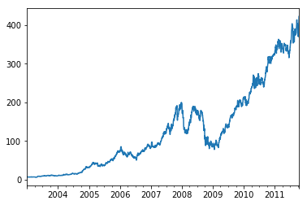

```python
plt.show()
```

```python
close_px.ix['2009'].plot()
```

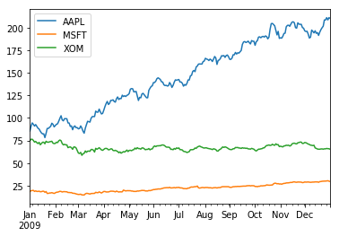

```python
plt.show()
```

```python
close_px['AAPL'].ix['01-2011':'03-2011'].plot()
```

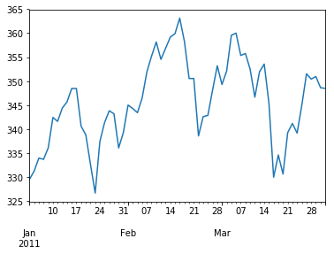

```python
plt.show()
```

```python
appl_q=close_px['AAPL'].resample('Q-DEC',fill_method='ffill')
```

```python
appl_q.ix['2009':].plot()
```

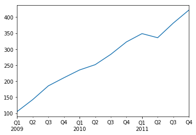

```python
plt.show()
```

# 八、移动窗口函数

在移动窗口（可带有指数衰减权数）上计算的各种统计函数也是一类常见于时间序列的数组变换。将其称为移动窗口函数，还包括那些窗口不定长的函数。移动窗口函数会自动排除缺失值

```python
close_px.AAPL.plot()
```

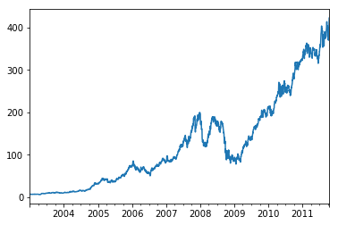

```python
plt.show()
```

rolling_mean是其中最简单的一个，接受一个TimeSeries或DataFrame以及一个window（表示期数）

```python
pd.rolling_mean(close_px.AAPL,250).plot()
```

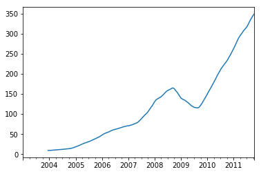

```python
plt.show()
```

```python
appl_std250=pd.rolling_std(close_px.AAPL,250,min_periods=10)
```

```python
appl_std250[5:12]
```

```
2003-01-09         NaN
2003-01-10         NaN
2003-01-13         NaN
2003-01-14         NaN
2003-01-15    0.077496
2003-01-16    0.074760
2003-01-17    0.112368
Freq: B, Name: AAPL, dtype: float64
```

```python
appl_std250.plot()
```

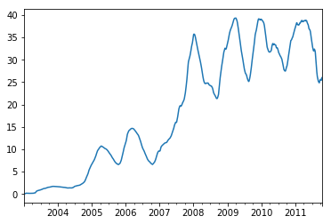

```python
plt.show()
```

计算扩展窗口平均，可将扩展窗口看做是一个特殊的窗口，其长度与时间序列一样，但只需一期或多期即可计算一个值

```python
expanding_mean=lambda x:rolling_mean(x,len(x),min_periods=1)
```

```python
pd.rolling_mean(close_px,60).plot(logy=True)
```

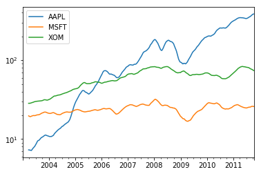

```python
plt.show()
```

[figure not shown]

## 1、指数加权函数

另一种使用固定大小窗口及相等权数观测值得方法是，定义一个衰减因子常量，以便是近期的观测值拥有更大的权数

```python
fig,axes=plt.subplots(nrows=2,ncols=1,sharex=True,sharey=True,figsize=(12,7))
```

```python
aapl_px=close_px.AAPL['2005':'2009']
```

```python
ma60=pd.rolling_mean(aapl_px,60,min_periods=50)
```

```python
ewma60=pd.ewma(aapl_px,span=60)
```

```python
aapl_px.plot(style='k-',ax=axes[0])
```

```python
ma60.plot(style='k--',ax=axes[0])
```

```python
ewma60.plot(style='k-',ax=axes[1])
```

```python
aapl_px.plot(style='k--',ax=axes[1])
```

```python
axes[0].set_title('Simple MA')
```

```python
axes[1].set_title('Exponentially-weighted MA')
```

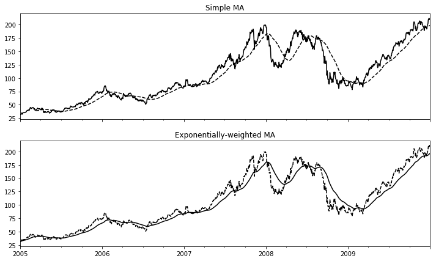

```python
plt.show()
```

## 2、二元移动窗口函数

```python
spx_px=close_px_all['SPX']
```

```python
spx_rets=spx_px/spx_px.shift(1)-1
```

```python
returns=close_px.pct_change()
```

```python
corr=pd.rolling_corr(returns.AAPL,spx_rets,125,min_periods=100)
```

```python
corr.plot()
```

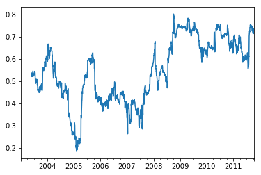

```python
plt.show()
```

```python
corr=pd.rolling_corr(returns,spx_rets,125,min_periods=100)
```

```python
corr.plot()
```

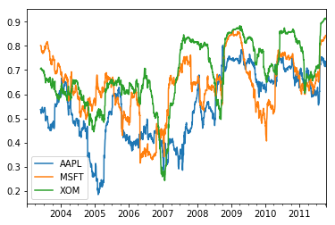

```python
plt.show()
```

## 3、用户定义的移动窗口函数

rolling_apply函数能使你在移动窗口上应用自己设计的数组函数，该函数要能从数组的各个片段中产生单个值（即约简）

```python
from scipy.stats import percentileofscore
```

```python
score_at_2percent=lambda x:percentileofscore(x,0.02)
```

```python
result=pd.rolling_apply(returns.AAPL,250,score_at_2percent)
```

```python
result.plot()
```

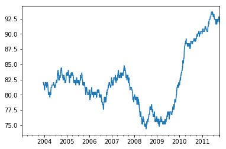

```python
plt.show()
```

# 九、性能和内存使用方面的注意事项

pandas会尽量在多个时间序列之间共享索引，所以创建现有时间序列的视图不会占用更多内存。此外，低频率索引（日以上）会被存放在一个中心缓存中，所以任何固定频率的索引都是该日期缓存的视图

```python
rng=pd.date_range('1/1/2000',periods=10000,freq='10ms')
```

```python
ts=Series(np.random.randn(len(rng)),index=rng)
```

```python
ts
```

```
2000-01-01 00:00:00.000   -2.940690
2000-01-01 00:00:00.010    0.598330
2000-01-01 00:00:00.020   -0.783687
2000-01-01 00:00:00.030   -1.789777
2000-01-01 00:00:00.040    0.192361
2000-01-01 00:00:00.050   -0.955834
2000-01-01 00:00:00.060    0.335664
2000-01-01 00:00:00.070   -1.855691
2000-01-01 00:00:00.080    0.129430
2000-01-01 00:00:00.090   -0.471917
2000-01-01 00:00:00.100   -0.235584
2000-01-01 00:00:00.110    1.139074
2000-01-01 00:00:00.120    1.864298
2000-01-01 00:00:00.130   -0.693764
2000-01-01 00:00:00.140    0.477258
2000-01-01 00:00:00.150   -1.038839
2000-01-01 00:00:00.160    0.205126
2000-01-01 00:00:00.170    0.010365
2000-01-01 00:00:00.180    0.295213
2000-01-01 00:00:00.190   -0.612395
2000-01-01 00:00:00.200   -1.823640
2000-01-01 00:00:00.210   -2.257709
2000-01-01 00:00:00.220    0.545340
2000-01-01 00:00:00.230    0.611568
2000-01-01 00:00:00.240   -0.059494
2000-01-01 00:00:00.250    1.292014
2000-01-01 00:00:00.260    2.497363
2000-01-01 00:00:00.270   -0.910875
2000-01-01 00:00:00.280    1.069877
2000-01-01 00:00:00.290    0.316078
                             ...
2000-01-01 00:01:39.700   -0.053049
2000-01-01 00:01:39.710    0.216422
2000-01-01 00:01:39.720    0.874826
2000-01-01 00:01:39.730    0.054448
2000-01-01 00:01:39.740   -0.158721
2000-01-01 00:01:39.750   -0.505171
2000-01-01 00:01:39.760    0.186995
2000-01-01 00:01:39.770   -0.505971
2000-01-01 00:01:39.780   -1.416973
2000-01-01 00:01:39.790    0.850319
2000-01-01 00:01:39.800    1.842772
2000-01-01 00:01:39.810    0.286034
2000-01-01 00:01:39.820    0.009118
2000-01-01 00:01:39.830   -0.635446
2000-01-01 00:01:39.840   -1.261981
2000-01-01 00:01:39.850    0.690988
2000-01-01 00:01:39.860   -0.810631
2000-01-01 00:01:39.870   -0.997262
2000-01-01 00:01:39.880    0.038216
2000-01-01 00:01:39.890   -0.304384
2000-01-01 00:01:39.900   -0.499081
2000-01-01 00:01:39.910    0.752222
2000-01-01 00:01:39.920   -1.767676
2000-01-01 00:01:39.930   -0.353179
2000-01-01 00:01:39.940    1.340152
2000-01-01 00:01:39.950    1.278139
2000-01-01 00:01:39.960    1.973800
2000-01-01 00:01:39.970   -0.073019
2000-01-01 00:01:39.980    1.662535
2000-01-01 00:01:39.990    0.830964
Freq: 10L, Length: 10000, dtype: float64
```

```python
ts.resample('10s',how='ohlc')
```

|  | open | high | low | close |
| --- | --- | --- | --- | --- |
| 2000-01-01 00:00:00 | -2.940690 | 3.491188 | -3.263552 | 0.102217 |
| 2000-01-01 00:00:10 | 0.124550 | 3.055318 | -3.170731 | -1.672249 |
| 2000-01-01 00:00:20 | -0.739956 | 3.692528 | -3.046537 | 0.884788 |
| 2000-01-01 00:00:30 | 0.647926 | 2.893253 | -3.644329 | 1.854966 |
| 2000-01-01 00:00:40 | 0.593976 | 3.493532 | -3.560204 | 1.653658 |
| 2000-01-01 00:00:50 | 0.422548 | 3.271777 | -2.973528 | 0.200047 |
| 2000-01-01 00:01:00 | 0.296989 | 3.892192 | -3.951279 | 1.513175 |
| 2000-01-01 00:01:10 | 1.470331 | 2.881332 | -3.360613 | 1.383346 |
| 2000-01-01 00:01:20 | -0.044636 | 3.346116 | -3.714478 | 1.175401 |
| 2000-01-01 00:01:30 | 0.895566 | 3.905321 | -3.529703 | 0.830964 |

```python
%timeit ts.resample('10s',how='ohlc')
```

```
1000 loops, best of 3: 1.15 ms per loop
```

运行时间跟聚合结果的相对大小有一定关系，越高频率的聚合所耗费的时间越多

```python
rng=pd.date_range('1/1/2000',periods=10000,freq='1s')
```

```python
ts=Series(np.random.randn(len(rng)),index=rng)
```

```python
ts.resample('10ms',how='ohlc')
```

|  | open | high | low | close |
| --- | --- | --- | --- | --- |
| 2000-01-01 00:00:00.000 | 1.444855 | 1.444855 | 1.444855 | 1.444855 |
| 2000-01-01 00:00:00.010 | NaN | NaN | NaN | NaN |
| 2000-01-01 00:00:00.020 | NaN | NaN | NaN | NaN |
| 2000-01-01 00:00:00.030 | NaN | NaN | NaN | NaN |
| 2000-01-01 00:00:00.040 | NaN | NaN | NaN | NaN |
| 2000-01-01 00:00:00.050 | NaN | NaN | NaN | NaN |
| 2000-01-01 00:00:00.060 | NaN | NaN | NaN | NaN |
| 2000-01-01 00:00:00.070 | NaN | NaN | NaN | NaN |
| 2000-01-01 00:00:00.080 | NaN | NaN | NaN | NaN |
| 2000-01-01 00:00:00.090 | NaN | NaN | NaN | NaN |
| 2000-01-01 00:00:00.100 | NaN | NaN | NaN | NaN |
| 2000-01-01 00:00:00.110 | NaN | NaN | NaN | NaN |
| 2000-01-01 00:00:00.120 | NaN | NaN | NaN | NaN |
| 2000-01-01 00:00:00.130 | NaN | NaN | NaN | NaN |
| 2000-01-01 00:00:00.140 | NaN | NaN | NaN | NaN |
| 2000-01-01 00:00:00.150 | NaN | NaN | NaN | NaN |
| 2000-01-01 00:00:00.160 | NaN | NaN | NaN | NaN |
| 2000-01-01 00:00:00.170 | NaN | NaN | NaN | NaN |
| 2000-01-01 00:00:00.180 | NaN | NaN | NaN | NaN |
| 2000-01-01 00:00:00.190 | NaN | NaN | NaN | NaN |
| 2000-01-01 00:00:00.200 | NaN | NaN | NaN | NaN |
| 2000-01-01 00:00:00.210 | NaN | NaN | NaN | NaN |
| 2000-01-01 00:00:00.220 | NaN | NaN | NaN | NaN |
| 2000-01-01 00:00:00.230 | NaN | NaN | NaN | NaN |
| 2000-01-01 00:00:00.240 | NaN | NaN | NaN | NaN |
| 2000-01-01 00:00:00.250 | NaN | NaN | NaN | NaN |
| 2000-01-01 00:00:00.260 | NaN | NaN | NaN | NaN |
| 2000-01-01 00:00:00.270 | NaN | NaN | NaN | NaN |
| 2000-01-01 00:00:00.280 | NaN | NaN | NaN | NaN |
| 2000-01-01 00:00:00.290 | NaN | NaN | NaN | NaN |
| ... | ... | ... | ... | ... |
| 2000-01-01 02:46:38.710 | NaN | NaN | NaN | NaN |
| 2000-01-01 02:46:38.720 | NaN | NaN | NaN | NaN |
| 2000-01-01 02:46:38.730 | NaN | NaN | NaN | NaN |
| 2000-01-01 02:46:38.740 | NaN | NaN | NaN | NaN |
| 2000-01-01 02:46:38.750 | NaN | NaN | NaN | NaN |
| 2000-01-01 02:46:38.760 | NaN | NaN | NaN | NaN |
| 2000-01-01 02:46:38.770 | NaN | NaN | NaN | NaN |
| 2000-01-01 02:46:38.780 | NaN | NaN | NaN | NaN |
| 2000-01-01 02:46:38.790 | NaN | NaN | NaN | NaN |
| 2000-01-01 02:46:38.800 | NaN | NaN | NaN | NaN |
| 2000-01-01 02:46:38.810 | NaN | NaN | NaN | NaN |
| 2000-01-01 02:46:38.820 | NaN | NaN | NaN | NaN |
| 2000-01-01 02:46:38.830 | NaN | NaN | NaN | NaN |
| 2000-01-01 02:46:38.840 | NaN | NaN | NaN | NaN |
| 2000-01-01 02:46:38.850 | NaN | NaN | NaN | NaN |
| 2000-01-01 02:46:38.860 | NaN | NaN | NaN | NaN |
| 2000-01-01 02:46:38.870 | NaN | NaN | NaN | NaN |
| 2000-01-01 02:46:38.880 | NaN | NaN | NaN | NaN |
| 2000-01-01 02:46:38.890 | NaN | NaN | NaN | NaN |
| 2000-01-01 02:46:38.900 | NaN | NaN | NaN | NaN |
| 2000-01-01 02:46:38.910 | NaN | NaN | NaN | NaN |
| 2000-01-01 02:46:38.920 | NaN | NaN | NaN | NaN |
| 2000-01-01 02:46:38.930 | NaN | NaN | NaN | NaN |
| 2000-01-01 02:46:38.940 | NaN | NaN | NaN | NaN |
| 2000-01-01 02:46:38.950 | NaN | NaN | NaN | NaN |
| 2000-01-01 02:46:38.960 | NaN | NaN | NaN | NaN |
| 2000-01-01 02:46:38.970 | NaN | NaN | NaN | NaN |
| 2000-01-01 02:46:38.980 | NaN | NaN | NaN | NaN |
| 2000-01-01 02:46:38.990 | NaN | NaN | NaN | NaN |
| 2000-01-01 02:46:39.000 | -0.130926 | -0.130926 | -0.130926 | -0.130926 |

999901 rows × 4 columns

```python
%timeit ts.resample('10ms',how='ohlc')
```

```
10 loops, best of 3: 40.6 ms per loop
```